# 242A HW2

```python
import pandas as pd
import numpy as np
from statsmodels.stats.outliers_influence import variance_inflation_factor
import statsmodels.api as sm
import matplotlib.pyplot as plt
import seaborn as sns

from sklearn.metrics import confusion_matrix, roc_curve, auc, classification_report, accuracy_score
from sklearn.preprocessing import StandardScaler
from sklearn.svm import SVC
from sklearn.model_selection import GridSearchCV
from torchvision import datasets
```

```python
train = pd.read_csv("data/framingham_train.csv")
test = pd.read_csv("data/framingham_test.csv")

train.head()
```

|  | male | age | education | currentSmoker | cigsPerDay | BPMeds | prevalentStroke | prevalentHyp | diabetes | totChol | sysBP | diaBP | BMI | heartRate | glucose | TenYearCHD |
| --- | --- | --- | --- | --- | --- | --- | --- | --- | --- | --- | --- | --- | --- | --- | --- | --- |
| 0 | 0 | 63 | Some high school | 0 | 0 | 0 | 0 | 1 | 0 | 293 | 193.0 | 63.0 | 30.00 | 70 | 76 | 1 |
| 1 | 1 | 41 | High school/GED | 1 | 40 | 0 | 0 | 0 | 0 | 310 | 117.5 | 80.0 | 26.74 | 80 | 78 | 0 |
| 2 | 1 | 58 | Some college/vocational school | 0 | 0 | 0 | 0 | 0 | 0 | 250 | 109.0 | 78.5 | 25.26 | 90 | 83 | 0 |
| 3 | 1 | 43 | Some high school | 1 | 43 | 0 | 0 | 0 | 0 | 215 | 122.0 | 76.0 | 26.84 | 85 | 74 | 0 |
| 4 | 1 | 46 | College | 0 | 0 | 0 | 0 | 1 | 0 | 220 | 136.5 | 99.5 | 27.78 | 80 | 70 | 0 |

Make education categorical (numerical)

```python
train = pd.get_dummies(train, columns=["education"], drop_first=True)
test = pd.get_dummies(test, columns=["education"], drop_first=True)
train.head()
```

|  | male | age | currentSmoker | cigsPerDay | BPMeds | prevalentStroke | prevalentHyp | diabetes | totChol | sysBP | diaBP | BMI | heartRate | glucose | TenYearCHD | education_High school/GED | education_Some college/vocational school | education_Some high school |
| --- | --- | --- | --- | --- | --- | --- | --- | --- | --- | --- | --- | --- | --- | --- | --- | --- | --- | --- |
| 0 | 0 | 63 | 0 | 0 | 0 | 0 | 1 | 0 | 293 | 193.0 | 63.0 | 30.00 | 70 | 76 | 1 | False | False | True |
| 1 | 1 | 41 | 1 | 40 | 0 | 0 | 0 | 0 | 310 | 117.5 | 80.0 | 26.74 | 80 | 78 | 0 | True | False | False |
| 2 | 1 | 58 | 0 | 0 | 0 | 0 | 0 | 0 | 250 | 109.0 | 78.5 | 25.26 | 90 | 83 | 0 | False | True | False |
| 3 | 1 | 43 | 1 | 43 | 0 | 0 | 0 | 0 | 215 | 122.0 | 76.0 | 26.84 | 85 | 74 | 0 | False | False | True |
| 4 | 1 | 46 | 0 | 0 | 0 | 0 | 1 | 0 | 220 | 136.5 | 99.5 | 27.78 | 80 | 70 | 0 | False | False | False |

## Exploratory Data Analysis

This step is important, because we need to understand whether any of our variables exhibit multicollinearity. This will help us model better later on

```python
print(train.shape)
print(train.dtypes)

# Target prevalence
print("TenYearCHD rate:", train["TenYearCHD"].mean().round(3))

# Missingness
missing = train.isna().mean().sort_values(ascending=False)
display(missing[missing > 0])
```

```
(2560, 18)
male                                          int64
age                                           int64
currentSmoker                                 int64
cigsPerDay                                    int64
BPMeds                                        int64
prevalentStroke                               int64
prevalentHyp                                  int64
diabetes                                      int64
totChol                                       int64
sysBP                                       float64
diaBP                                       float64
BMI                                         float64
heartRate                                     int64
glucose                                       int64
TenYearCHD                                    int64
education_High school/GED                      bool
education_Some college/vocational school       bool
education_Some high school                     bool
dtype: object
TenYearCHD rate: 0.155
```

```
Series([], dtype: float64)
```

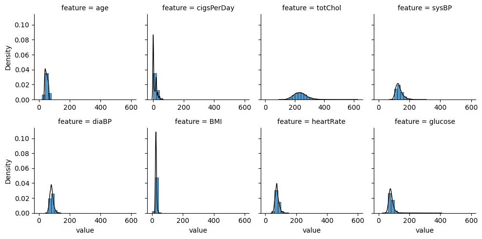

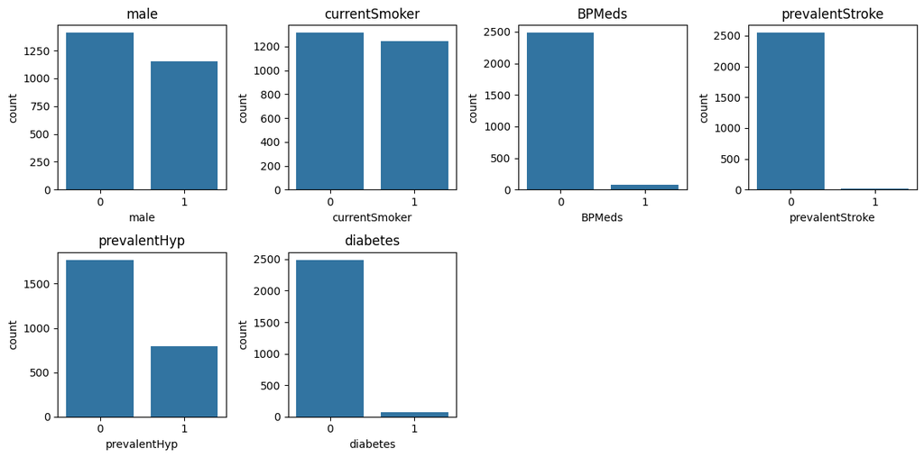

```
glucose       0.009375
cigsPerDay    0.003125
BMI           0.002734
heartRate     0.002344
sysBP         0.001953
diaBP         0.001953
totChol       0.001563
dtype: float64
```

```python
cont = ["age", "cigsPerDay", "totChol", "sysBP", "diaBP", "BMI", "heartRate", "glucose"]
bin_cols = [
    "male",
    "currentSmoker",
    "BPMeds",
    "prevalentStroke",
    "prevalentHyp",
    "diabetes",
]

long = train[cont].melt(var_name="feature", value_name="value")

# Histograms
g = sns.displot(
    data=long,
    x="value",
    col="feature",
    col_wrap=4,
    kind="hist",
    bins=30,
    stat="density",
    common_norm=False,
    height=2.5,
    facet_kws=dict(sharex=False),
)
g.map_dataframe(sns.kdeplot, x="value", color="k", lw=1, fill=False)
plt.show()

# Binary counts
fig, axes = plt.subplots(
    nrows=int(np.ceil(len(bin_cols) / 4)), ncols=4, figsize=(12, 6)
)
axes = axes.flatten()
for ax, col in zip(axes, bin_cols):
    sns.countplot(data=train, x=col, ax=ax)
    ax.set_title(col)
for ax in axes[len(bin_cols) :]:
    ax.axis("off")
plt.tight_layout()
plt.show()

# Simple outlier flag
z = np.abs((train[cont] - train[cont].mean()) / train[cont].std(ddof=0))
outlier_rate = (z > 4).mean().sort_values(ascending=False)
display(outlier_rate[outlier_rate > 0])

# feature
```

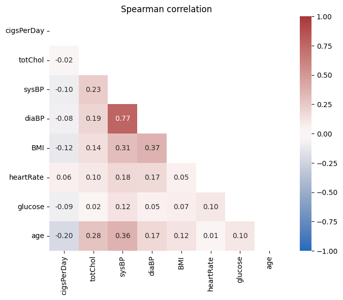

```python
corr = train[
    [
        "cigsPerDay",
        "totChol",
        "sysBP",
        "diaBP",
        "BMI",
        "heartRate",
        "glucose",
        "age",
    ]
].corr(method="spearman")
mask = np.triu(np.ones_like(corr, dtype=bool))
plt.figure(figsize=(8, 6))
sns.heatmap(
    corr, mask=mask, cmap="vlag", annot=True, fmt=".2f", vmin=-1, vmax=1, square=True
)
plt.title("Spearman correlation")
plt.show()
```

Looks like sysBP and diaBP might be collinear...so we should check with VIF eventually

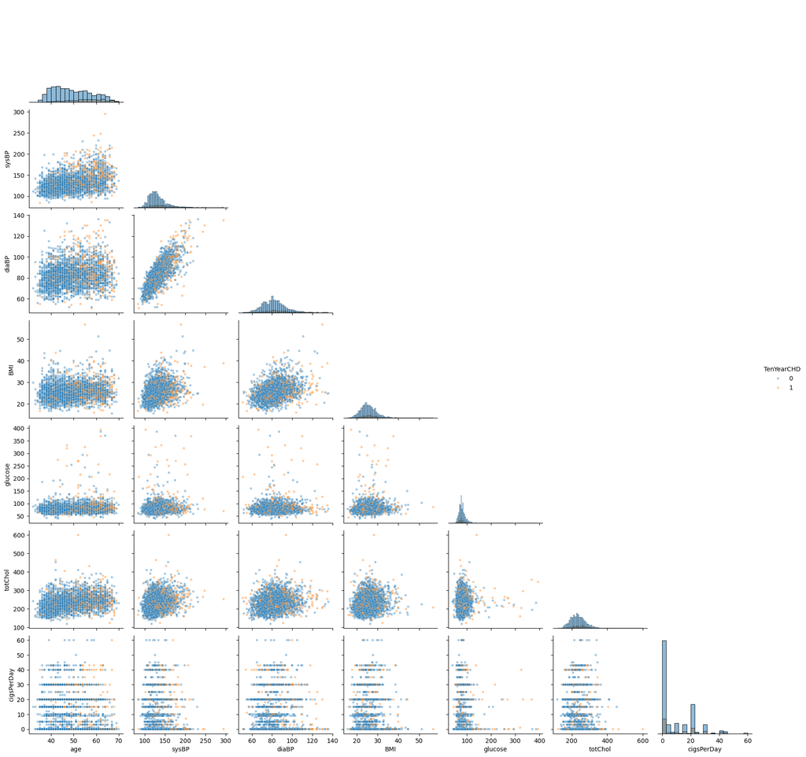

```python
plot_cols = [
    "age",
    "sysBP",
    "diaBP",
    "BMI",
    "glucose",
    "totChol",
    "cigsPerDay",
    "TenYearCHD",
]
sns.pairplot(
    train[plot_cols],
    hue="TenYearCHD",
    corner=True,
    diag_kind="hist",
    plot_kws={"alpha": 0.4, "s": 15},
)
plt.show()
```

```python
# Categorical/binary vs target
for col in [
    "male",
    "currentSmoker",
    "BPMeds",
    "prevalentStroke",
    "prevalentHyp",
    "diabetes",
    "education_High school/GED",
    "education_Some college/vocational school",
    "education_Some high school",
]:
    ct = pd.crosstab(train[col], train["TenYearCHD"], normalize="index").round(3)
    display(ct)
```

| TenYearCHD male | 0 | 1 |
| --- | --- | --- |
| 0 | 0.874 | 0.126 |
| 1 | 0.809 | 0.191 |

| TenYearCHD currentSmoker | 0 | 1 |
| --- | --- | --- |
| 0 | 0.863 | 0.137 |
| 1 | 0.826 | 0.174 |

| TenYearCHD BPMeds | 0 | 1 |
| --- | --- | --- |
| 0 | 0.852 | 0.148 |
| 1 | 0.628 | 0.372 |

| TenYearCHD prevalentStroke | 0 | 1 |
| --- | --- | --- |
| 0 | 0.846 | 0.154 |
| 1 | 0.625 | 0.375 |

| TenYearCHD prevalentHyp | 0 | 1 |
| --- | --- | --- |
| 0 | 0.888 | 0.112 |
| 1 | 0.749 | 0.251 |

| TenYearCHD diabetes | 0 | 1 |
| --- | --- | --- |
| 0 | 0.850 | 0.150 |
| 1 | 0.658 | 0.342 |

| TenYearCHD education_High school/GED | 0 | 1 |
| --- | --- | --- |
| False | 0.831 | 0.169 |
| True | 0.876 | 0.124 |

| TenYearCHD education_Some college/vocational school | 0 | 1 |
| --- | --- | --- |
| False | 0.840 | 0.160 |
| True | 0.868 | 0.132 |

| TenYearCHD education_Some high school | 0 | 1 |
| --- | --- | --- |
| False | 0.870 | 0.130 |
| True | 0.809 | 0.191 |

### VIF & Multicollinearity

```python
# Choose modeling features (drop one education dummy to avoid perfect multicollinearity)
feature_cols = [
    "male",
    "age",
    "currentSmoker",
    "cigsPerDay",
    "BPMeds",
    "prevalentStroke",
    "prevalentHyp",
    "diabetes",
    "totChol",
    "sysBP",
    "diaBP",
    "BMI",
    "heartRate",
    "glucose",
    "education_High school/GED",
    "education_Some college/vocational school",
    "education_Some high school",
]


def generate_vif(df: pd.DataFrame, features: list[str]) -> None:
    X = df[features].dropna()
    X_scaled = pd.DataFrame(StandardScaler().fit_transform(X), columns=X.columns)

    # generate the VIFs
    vifs = pd.Series(
        [
            variance_inflation_factor(X_scaled.values, i)
            for i in range(X_scaled.shape[1])
        ],
        index=X_scaled.columns,
    ).sort_values(ascending=False)

    display(vifs)


generate_vif(train, feature_cols)
```

```
sysBP                                       3.659810
diaBP                                       2.934512
cigsPerDay                                  2.772941
education_Some high school                  2.759506
currentSmoker                               2.606589
education_High school/GED                   2.565528
education_Some college/vocational school    2.070322
prevalentHyp                                1.993042
glucose                                     1.595450
diabetes                                    1.578650
age                                         1.371917
male                                        1.238184
BMI                                         1.216952
BPMeds                                      1.122977
totChol                                     1.118508
heartRate                                   1.093504
prevalentStroke                             1.023076
dtype: float64
```

### Interpretations from EDA

Before I interpret all the charts and information from above, first, let's level set on some contextual knowledge.

**1. If you have 0 cigs per day, you are a non-smoker**

The data seems to already encode that. Logically, I can write a (non-linear) function that perfectly maps the number of cigs that someone has into a binary variable into whether they have a cigarette or not

$$ \text{Smoker} = \begin{cases} 0 & \text{ if cigsPerDay = 0} \\ 1 & \text{ otherwise} \end{cases} $$

So, we'll remove `cigsPerDay` from our dataset, to keep the model simpler and more stable, and because I'm only interested in the effect of smoking or not on CHD likelihood

**2. sysBP and diaBP are two sides of BP**

Some defintions:

- `sysBP`: the peak arterial pressure during heart contraction.
- `diaBP`: trough pressure during relaxation

It makes sense for both to be related, however, existing medical literature (including the original one for this problem) suggests that we should preserve both variables. Summary of Gemini's response below:

> 🤖 Thanks Gemini!

> **Prompt**: what does existing medical research tells us about the relationship between sysBP and diaBP to coronary heart disease? explain your results to a packed auditorium full of statisticians and medical professionals

> **Response**:
> 1. SBP is the dominant predictor in the general population, especially in middle-aged and older adults. Its relationship to risk is robust, continuous, and log-linear.
> 2. Pulse Pressure is a critical derived variable that often outperforms DBP as a predictor in older populations, as it captures the net effect of arterial stiffening.
> 3. DBP remains an independent predictor, especially in younger adults. Its primary statistical curiosity is the J-curve relationship in high-risk patients, where low DBP ($< 70 \text{ mmHg}$) is associated with increased adverse coronary events, a finding with profound clinical and therapeutic implications.

### Observations from EDA:

1. sysBP and diaBP: a high correlation between them. However as stated above, we will keep both in the model
2. Most of the categorical variables are correlating with an increase in CHD risk
3. In contrast with (2), smoking seems to correlate less – however, this is relative to the other categorical variables, which mainly are about pre-existing heart conditions. From that perspective, it makes sense.
4. Age seems to be the strongest determinant, from the pair-plots. Higher age seems to lead to likelier CHD
5. For the other variables, nothing appears out of the orinary to explain CHD risk

### Outcomes

1. I'd remove cigsPerDay
2. Keep everything else
3. Watch out for age being a strong explainer

## Question 1a

- Build a logistic regression model to predict the probability that a patient will experience CHD within the next 10 years using framingham_train.csv
- Test using framinghamg_Test.csv
- Use the model and details from @config.py to recommend to a policy maker about the treatment
- **Use all the variables**

```python
Y = train["TenYearCHD"]
X_train = train.drop(columns=["TenYearCHD"])

# convert the boolean true/false to 1/0
X_train = X_train.astype(int)

X_train_with_constant = sm.add_constant(X_train)

model = sm.Logit(Y, X_train_with_constant)
# sk_model = LogisticRegression(max_iter=3000).fit(X_train, Y)
results = model.fit()
results.summary()
```

```
Optimization terminated successfully.
         Current function value: 0.375940
         Iterations 7
```

Logit Regression Results

| Dep. Variable: | TenYearCHD | No. Observations: | 2560 |
| --- | --- | --- | --- |
| Model: | Logit | Df Residuals: | 2542 |
| Method: | MLE | Df Model: | 17 |
| Date: | Fri, 17 Oct 2025 | Pseudo R-squ.: | 0.1286 |
| Time: | 18:20:48 | Log-Likelihood: | -962.41 |
| converged: | True | LL-Null: | -1104.4 |
| Covariance Type: | nonrobust | LLR p-value: | 2.187e-50 |

|  | coef | std err | z | P>\|z\| | [0.025 | 0.975] |
| --- | --- | --- | --- | --- | --- | --- |
| const | -9.1186 | 0.839 | -10.868 | 0.000 | -10.763 | -7.474 |
| male | 0.4205 | 0.133 | 3.170 | 0.002 | 0.161 | 0.681 |
| age | 0.0713 | 0.008 | 8.844 | 0.000 | 0.055 | 0.087 |
| currentSmoker | 0.1528 | 0.185 | 0.825 | 0.409 | -0.210 | 0.516 |
| cigsPerDay | 0.0249 | 0.007 | 3.471 | 0.001 | 0.011 | 0.039 |
| BPMeds | 0.2870 | 0.274 | 1.047 | 0.295 | -0.250 | 0.824 |
| prevalentStroke | 0.7950 | 0.571 | 1.392 | 0.164 | -0.324 | 1.914 |
| prevalentHyp | 0.2197 | 0.163 | 1.344 | 0.179 | -0.101 | 0.540 |
| diabetes | -0.0496 | 0.368 | -0.135 | 0.893 | -0.771 | 0.671 |
| totChol | 0.0028 | 0.001 | 2.046 | 0.041 | 0.000 | 0.005 |
| sysBP | 0.0090 | 0.004 | 2.002 | 0.045 | 0.000 | 0.018 |
| diaBP | 0.0080 | 0.008 | 1.027 | 0.305 | -0.007 | 0.023 |
| BMI | 0.0072 | 0.015 | 0.475 | 0.635 | -0.023 | 0.037 |
| heartRate | -0.0042 | 0.005 | -0.849 | 0.396 | -0.014 | 0.006 |
| glucose | 0.0082 | 0.003 | 3.180 | 0.001 | 0.003 | 0.013 |
| education_High school/GED | -0.1220 | 0.211 | -0.579 | 0.562 | -0.535 | 0.291 |
| education_Some college/vocational school | -0.0870 | 0.233 | -0.374 | 0.709 | -0.544 | 0.370 |
| education_Some high school | 0.0509 | 0.196 | 0.259 | 0.795 | -0.334 | 0.436 |

### (i) What is the fitted logistic regression model? Do not simply copy the results of your code, but instead state the equation used by the model to make predictions. Use all features from Table 1 to build your model

Logistic regression in general outputs equations of the form:

$$ \ln\left(\frac{P}{1 - P}\right) = \beta_0 + \beta_1 X_1 + \beta_2 X_2 + \dots + \beta_k X_k $$

In our case, the predicted variable is the event of a 10-year coronary heart disease occuring. My model predicts:

$$ \ln\left(\frac{P(\text{TenYearCHD})}{1 - P(\text{TenYearCHD})}\right) = -9.1186 + 0.4205 \cdot \text{Male} + 0.0713 \cdot \text{Age} + 0.1528 \cdot \text{CurrentSmoker} + 0.0249 \cdot \text{CigsPerDay} + 0.2870 \cdot \text{BPMeds} + 0.7950 \cdot \text{PrevalentStroke} + 0.2197 \cdot \text{PrevalentHyp} - 0.0496 \cdot \text{Diabetes} + 0.0028 \cdot \text{TotChol} + 0.0090 \cdot \text{SysBP} + 0.0080 \cdot \text{DiaBP} + 0.0072 \cdot \text{BMI} - 0.0042 \cdot \text{HeartRate} + 0.0082 \cdot \text{Glucose} - 0.1220 \cdot \text{Educ}_{\text{HS/GED}} - 0.0870 \cdot \text{Educ}_{\text{SomeCollege}} + 0.0509 \cdot \text{Educ}_{\text{SomeHS}} $$

### (ii) What are the most important risk factors for 10-year CHD risk identified by the model? Pick one of these variables and describe its impact on a patient’s predicted odds of developing CHD in the next 10 years.

The most important risk factors are:

### (iii) Suppose that you wish to determine the optimal strategy for assigning which new patients receive the medication. Given your colleague’s analysis of the costs and benefits associated with the recently approved treatment, identify a threshold value of p, call it $\bar{p}$, such that it is optimal to prescribe the medication to a patient if and only if their 10-year CHD risk exceeds $\bar{p}$

The idea here is to use the decision nodes from my colleague's analysis to determine "the point of indifference" – that is, the point where prescribing and not prescribing have the same expected value.

$$\begin{align*} \text{EV}_{\text{Prescribe}} &= \text{EV}_{\text{Do Not Prescribe}} \\[0.5em] (0.10p) \cdot (1,050,000) + (1 - 0.10p) \cdot (95,000) &= (p) \cdot (955,000) + (1 - p) \cdot (0) \\[0.5em] 105,000p + 95,000 - 9,500p &= 955,000p \\[0.5em] 95,500p + 95,000 &= 955,000p \\[0.5em] 95,000 &= 955,000p - 95,500p \\[0.5em] 95,000 &= 859,500p \\[0.5em] \bar{p} &= \frac{95,000}{859,500} \\[0.5em] \bar{p} &\approx 0.1105 \end{align*} $$

### (iv) Describe the test set performance of the logistic regression model, using the threshold identified in (iii) to separate patients into those who are at high risk for CHD (risk exceeding the threshold ¯p) and those who are at low risk for CHD (risk below the threshold $\bar{p}$). State the model’s accuracy, True Positive Rate (TPR), and False Positive Rate (FPR), and briefly describe these three metrics in a way that is accessible to a non-technical audience.

```python
threshold = 0.1105

# I'll use sk_model here – both have approximately very close coefficient values
X_test = test.drop(columns=["TenYearCHD"])
X_test = X_test.astype(int)
Y_test_outcomes = test["TenYearCHD"]
Y_predicted_probabilities = results.predict(sm.add_constant(X_test))
Y_predicted_outcomes = (Y_predicted_probabilities > threshold).astype(int)

cm = confusion_matrix(Y_test_outcomes, Y_predicted_outcomes)
TN, FP, FN, TP = cm.ravel()

accuracy = (TP + FP) / (TP + FP + TN + FN)
TPR = TP / (TP + FN)
FPR = FP / (FP + TN)
print(accuracy, TPR, FPR)
```

```
0.5127504553734062 0.775 0.4680170575692964
```

### (v) If patients are prescribed the medication using the strategy implied by the model, use the test set data to provide an estimate(s) for the expected economic cost per patient. You should first report your estimate assuming that the CHD outcomes in the test set are not affected by the treatment decision. Is this assumption reasonable? You should then adjust your estimate in a way that takes into account the fact that the treatment decision impacts a patient’s risk of developing CHD. (Hint: keep in mind that this dataset was collected before the option of prescribing the medication was even considered.)

```python
tp_cost = 1050000
fp_cost = 95000
fn_cost = 955000
tn_cost = 0

tp_total_cost = tp_cost * TP
fp_total_cost = fp_cost * FP
tn_total_cost = tn_cost * TN
fn_total_cost = fn_cost * FN

total_cost = tp_total_cost + fp_total_cost + tn_total_cost + fn_total_cost
total_cost_per_patient = total_cost / X_test.shape[0]
print(f"Total Economic cost: ${total_cost_per_patient:,.0f}")
```

```
Total Economic cost: $187,873
```

The total economic cost per patient is $187,873. Calculated it by taking my colleague's analysis on the expected economic cost based on the decision tree. Each node of the decision tree represents one of the entries in the confusion matrix:

1. Prescribe medication, have CHD => True Positive
2. Prescribe medication, no CHD => False Positive
3. Not prescribe medication, have CHD => False Negative
4. Not prescribe medication, no CHD => True Negative

I know how many totals exist in those cases. To calculate overall economic cost, I can multiple the totals of each group (counts) times the economic cost. Then, averaging across all patients gives me the avg economic cost.

#### What about the assumption?

The assumption that the medication has no impact on the patient's risk to catch CHD is flawed. Each medication is prescribed to have a positive outcome, hopefully. We can assume that the medication works with some probability $p$, and then multiple the `TP` number by $p$, to denote that some proportion of those patients only succumbed to CHD.

```python
medication_success = 0.5

tp_cost_assuming_medicine_works = tp_cost * TP * medication_success

new_total_cost = (
    tp_cost_assuming_medicine_works + fp_total_cost + tn_total_cost + fn_total_cost
)
new_avg_cost_per_patient = new_total_cost / X_test.shape[0]
print(
    f"Total Economic Cost Assuming Medicine Works 50% of the time: ${new_avg_cost_per_patient:,.0f}"
)
```

```
Total Economic Cost Assuming Medicine Works 50% of the time: $128,584
```

### (vi) Consider a simple baseline model that predicts none of the patients are at high risk for CHD and therefore does not recommend treatment for any of the patients. Describe the test set performance of the baseline model in terms of accuracy, TPR, and FPR, as well as expected economic cost per patient.

```python
# the naive model would always output 0. We can calculate TPR / FPR / Accuracy for this
# also, TPR / FPR would definitely be 0 (since no positive predictions)
n_test = X_test.shape[0]
naive_output = np.zeros(n_test)
cm_naive = confusion_matrix(Y_test_outcomes, naive_output)

TN_naive, FP_naive, FN_naive, TP_naive = cm_naive.ravel()
accuracy_naive = (TP_naive + TN_naive) / sum([TN_naive, FP_naive, FN_naive, TP_naive])

tp_total_cost_naive = tp_cost * TP_naive
fp_total_cost_naive = fp_cost * FP_naive
tn_total_cost_naive = tn_cost * TN_naive
fn_total_cost_naive = fn_cost * FN_naive

total_cost_naive = (
    tp_total_cost_naive
    + fp_total_cost_naive
    + tn_total_cost_naive
    + fn_total_cost_naive
)
total_cost_per_patient_naive = total_cost_naive / X_test.shape[0]
print(f"Total Economic cost: ${total_cost_per_patient_naive:,.0f}")

print(accuracy_naive)
```

```
Total Economic cost: $139,162
0.8542805100182149
```

For the naive model:

1. Accuracy is 85.4%
2. TPR = 0%
3. FPR = 0%
4. Expected economic cost per patient is $139,162

### (vii) Use an example to explain how to use the model in a real clinical setting.

Suppose a new patient arrives, and the physician accesses the patient’s electronic medical records and retrieves the following about the patient:

> Female, age 39, GED education, currently a smoker with an average of 6 cigarettes per day. Currently not on blood pressure medication, has not had stroke and 3 is not hypertensive. Currently diagnosed with diabetes; total Cholesterol at 230. Systolic/diastolic blood pressure at 110/50, BMI at 28, heart rate at 72, glucose level at 80.

What is the predicted probability that this patient will experience CHD in the next ten years? Based on your calculated ¯p threshold from (iii) from the decision tree, should the physician prescribe the preventive medication for this patient?

```python
X_test.columns
```

```
Index(['male', 'age', 'currentSmoker', 'cigsPerDay', 'BPMeds',
       'prevalentStroke', 'prevalentHyp', 'diabetes', 'totChol', 'sysBP',
       'diaBP', 'BMI', 'heartRate', 'glucose', 'education_High school/GED',
       'education_Some college/vocational school',
       'education_Some high school'],
      dtype='object')
```

```python
len(X_test.columns)
```

```
17
```

```python
constant_column = ["constant"]
test_columns = list(X_test.columns)
columns = constant_column + test_columns
print(columns)

new_patient = pd.DataFrame(columns=columns)
new_patient.loc[0] = [1, 0, 39, 1, 6, 0, 0, 0, 1, 230, 110, 50, 28, 72, 80, 1, 0, 0]
# added first 1 for constant

new_patient_prediction = results.predict(new_patient)
print(new_patient_prediction, new_patient_prediction >= threshold)
```

```
['constant', 'male', 'age', 'currentSmoker', 'cigsPerDay', 'BPMeds', 'prevalentStroke', 'prevalentHyp', 'diabetes', 'totChol', 'sysBP', 'diaBP', 'BMI', 'heartRate', 'glucose', 'education_High school/GED', 'education_Some college/vocational school', 'education_Some high school']
0    0.025834
dtype: float64 0    False
dtype: bool
```

We will not prescribe the medication in this patient's case.

## Question 1b

- Show ROC
- Describe how it is helpful
- One interesting observation
- What is AUC?

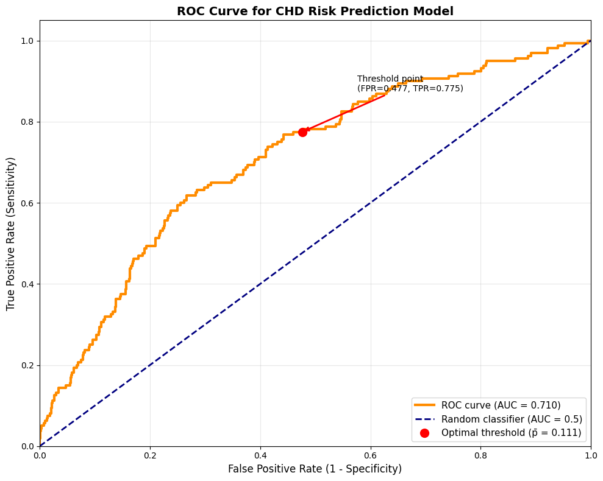

```
AUC (Area Under the Curve): 0.710
Threshold point: FPR = 0.477, TPR = 0.775
```

```python
# Calculate ROC curve and AUC
fpr, tpr, thresholds = roc_curve(Y_test_outcomes, Y_predicted_probabilities)
roc_auc = auc(fpr, tpr)

# Find the threshold point closest to our p_bar threshold
threshold_idx = np.argmin(np.abs(thresholds - threshold))
threshold_fpr = fpr[threshold_idx]
threshold_tpr = tpr[threshold_idx]

# Create comprehensive ROC curve plot
plt.figure(figsize=(10, 8))
plt.plot(fpr, tpr, color="darkorange", lw=3, label=f"ROC curve (AUC = {roc_auc:.3f})")
plt.plot(
    [0, 1],
    [0, 1],
    color="navy",
    lw=2,
    linestyle="--",
    label="Random classifier (AUC = 0.5)",
)

# Mark the optimal threshold point
plt.plot(
    threshold_fpr,
    threshold_tpr,
    "ro",
    markersize=10,
    label=f"Optimal threshold (p̄ = {threshold:.3f})",
)
plt.annotate(
    f"Threshold point\n(FPR={threshold_fpr:.3f}, TPR={threshold_tpr:.3f})",
    xy=(threshold_fpr, threshold_tpr),
    xytext=(threshold_fpr + 0.1, threshold_tpr + 0.1),
    arrowprops=dict(arrowstyle="->", color="red", lw=2),
)

plt.xlim([0.0, 1.0])
plt.ylim([0.0, 1.05])
plt.xlabel("False Positive Rate (1 - Specificity)", fontsize=12)
plt.ylabel("True Positive Rate (Sensitivity)", fontsize=12)
plt.title("ROC Curve for CHD Risk Prediction Model", fontsize=14, fontweight="bold")
plt.legend(loc="lower right", fontsize=11)
plt.grid(True, alpha=0.3)
plt.tight_layout()
plt.show()

print(f"AUC (Area Under the Curve): {roc_auc:.3f}")
print(f"Threshold point: FPR = {threshold_fpr:.3f}, TPR = {threshold_tpr:.3f}")
```

### How the ROC Curve Helps Decision-Makers

The ROC provides a view of the trade-offs between correctly identifying high-risk patients and avoiding unnecessary treatments for low-risk patients. Decision-makers can choose the optimal threshold based on their priorities - minimizing false positives or false negatives.

### Interesting Observation

**The optimal threshold seems to align with our economic costs**

### AUC Interpretation

**AUC = 0.710**

The AUC (Area Under the Curve) of 0.710 indicates that our model has good discrimination ability.

Our model's AUC of 0.710 suggests a good discrimination, meaning it can effectively distinguish between patients who will and will not develop CHD over the next 10 years.

## Question 1c

Insurance company would set a copayment amount equal to the expected cost of their payouts (+ some premium for a desired profit)

Let's assume the insurance company is benevolent and just wants to breakeven

> LOL 🤣

The insurance company would still want the patients to be indifferent to the choice of taking the medication or not. So, what's the expected patient cost if they are prescribed, or not prescribed the medication

$$ \begin{align} E_{prescribe} & = \text{Co-payment} + P(\text{CHD}|\text{Prescribe}) \cdot \text{Cost}_{\text{CHD}} \\ & = C + (0.10p) \cdot (\$625,000) \end{align} $$

$$ \begin{align} E_{not prescribe} & = P(\text{CHD}|\text{Not Prescribe}) \cdot \text{Cost}_{\text{CHD}} \\ & = (p) \cdot (\$625,000) \end{align} $$

Now, we know what $p$ should be – the optimal from the previous question. Plugging it in, we get

## Question 1d

Surely there are some problems with this analysis. A key one that comes to mind:

**Patients are not just economic units.**

They have autonomy and a set of preferences, which our entire analysis above (and our overall model) conveniently ignores. One way to quantify or account for this is to include a risk tolerance or additional features there as well, which represents the fact that people might have their own rationales for their own decisions

## Question 2

Make an SVM distinguishing 1 and 8

```python
train = datasets.MNIST(root="./data", train=True, download=True)
test = datasets.MNIST(root="./data", train=False, download=True)
```

```
100.0%
100.0%
100.0%
100.0%
```

```python
print(train)
```

```
Dataset MNIST
    Number of datapoints: 60000
    Root location: ./data
    Split: Train
```

First, need to make train and test into numpy arrays so we can work with it. We also should filter the image data to only includes images for 1 and 8

```python
# Convert to numpy arrays and filter for digits 1 and 8
train_data = train.data.numpy()
train_labels = train.targets.numpy()
test_data = test.data.numpy()
test_labels = test.targets.numpy()

# Filter for only digits 1 and 8
train_mask = (train_labels == 1) | (train_labels == 8)
test_mask = (test_labels == 1) | (test_labels == 8)

X_train = train_data[train_mask]
y_train = train_labels[train_mask]
X_test = test_data[test_mask]
y_test = test_labels[test_mask]

# Flatten the images (28x28 -> 784)
X_train = X_train.reshape(X_train.shape[0], -1)
X_test = X_test.reshape(X_test.shape[0], -1)

print(f"Training set: {X_train.shape[0]} samples, {X_train.shape[1]} features")
print(f"Test set: {X_test.shape[0]} samples, {X_test.shape[1]} features")
print(f"Class distribution in training: {np.bincount(y_train)}")
print(f"Class distribution in test: {np.bincount(y_test)}")
```

```
Training set: 12593 samples, 784 features
Test set: 2109 samples, 784 features
Class distribution in training: [   0 6742    0    0    0    0    0    0 5851]
Class distribution in test: [   0 1135    0    0    0    0    0    0  974]
```

Now, let's normalize all the data that's inside the training so because SVMs work better when the features are all on similar scales. Without normalization higher pixel values would dominate the decision boundary.

We'll also add binary labels for 1 / 8 so we can make decisions easier, and we'll start training the model

```python
# Normalize pixel values to [0, 1] range
X_train = X_train.astype(np.float32) / 255.0
X_test = X_test.astype(np.float32) / 255.0

# Convert labels to binary: 1 -> 0, 8 -> 1
y_train_binary = (y_train == 8).astype(np.int32)
y_test_binary = (y_test == 8).astype(np.int32)

print(f"Normalized pixel range: [{X_train.min():.3f}, {X_train.max():.3f}]")
print(f"Binary labels - Training: {np.bincount(y_train_binary)}")
print(f"Binary labels - Test: {np.bincount(y_test_binary)}")
print(f"Label mapping: 1 -> {0}, 8 -> {1}")
```

```
Normalized pixel range: [0.000, 1.000]
Binary labels - Training: [6742 5851]
Binary labels - Test: [1135  974]
Label mapping: 1 -> 0, 8 -> 1
```

Now, train the model. First tune the hyperparameter.

> 🤖 Thanks Cursor AI

> **Prompt**: let's definitely do k-fold cross validation to tune the hyper parameters. what hyper parameters are we tuning?

> **Response**: Great question! For a linear SVM, the main hyperparameter we need to tune is the C parameter (regularization strength). Let me explain the approach: Hyperparameters to tune:
> - C: Controls the trade-off between margin maximization and training error. Higher C = less regularization, more complex boundary
> - We could also tune class_weight if we want to handle class imbalance Cross-validation approach:
> - Use GridSearchCV with k-fold (typically 5-fold) to find optimal C
> - Test a range of C values (e.g., [0.001, 0.01, 0.1, 1, 10, 100])
> - Use accuracy as the scoring metric

```python
# Tune the hyperparameter C (regularization)
param_grid = {"C": [0.001, 0.01, 0.1, 1, 10, 100]}

# Create linear SVM
svm = SVC(kernel="linear", random_state=42)

# Perform 5-fold cross-validation
grid_search = GridSearchCV(
    svm,
    param_grid,
    cv=5,
    scoring="accuracy",
    n_jobs=-1,  # Use all available cores
    verbose=1,
)

print("Starting cross-validation...")
grid_search.fit(X_train, y_train_binary)

print(f"\nBest parameters: {grid_search.best_params_}")
print(f"Best cross-validation score: {grid_search.best_score_:.4f}")

# Get the best model
best_svm = grid_search.best_estimator_
```

```
Starting cross-validation...
Fitting 5 folds for each of 6 candidates, totalling 30 fits

Best parameters: {'C': 0.1}
Best cross-validation score: 0.9842
```

Great, we made our model. Now, let's test it.

```python
# Make predictions on test set
y_pred = best_svm.predict(X_test)

# Calculate accuracy
accuracy = accuracy_score(y_test_binary, y_pred)
print(f"Test Accuracy: {accuracy:.4f}")

# Confusion Matrix
cm = confusion_matrix(y_test_binary, y_pred)
print("\nConfusion Matrix:")
print(f"True Negatives (1s): {cm[0,0]}")
print(f"False Positives (1s predicted as 8s): {cm[0,1]}")
print(f"False Negatives (8s predicted as 1s): {cm[1,0]}")
print(f"True Positives (8s): {cm[1,1]}")

# Classification Report
print("\nClassification Report:")
print(classification_report(y_test_binary, y_pred, target_names=["Digit 1", "Digit 8"]))

# Show some example predictions
print("\nFirst 10 predictions vs actual:")
for i in range(10):
    actual_digit = 1 if y_test_binary[i] == 0 else 8
    predicted_digit = 1 if y_pred[i] == 0 else 8
    print(f"Sample {i}: Actual={actual_digit}, Predicted={predicted_digit}")
```

```
Test Accuracy: 0.9915

Confusion Matrix:
True Negatives (1s): 1126
False Positives (1s predicted as 8s): 9
False Negatives (8s predicted as 1s): 9
True Positives (8s): 965

Classification Report:
              precision    recall  f1-score   support

     Digit 1       0.99      0.99      0.99      1135
     Digit 8       0.99      0.99      0.99       974

    accuracy                           0.99      2109
   macro avg       0.99      0.99      0.99      2109
weighted avg       0.99      0.99      0.99      2109


First 10 predictions vs actual:
Sample 0: Actual=1, Predicted=1
Sample 1: Actual=1, Predicted=1
Sample 2: Actual=1, Predicted=1
Sample 3: Actual=1, Predicted=1
Sample 4: Actual=1, Predicted=1
Sample 5: Actual=1, Predicted=1
Sample 6: Actual=1, Predicted=1
Sample 7: Actual=1, Predicted=1
Sample 8: Actual=1, Predicted=1
Sample 9: Actual=1, Predicted=1
```

Not bad at all! You can actually see the model in action too...

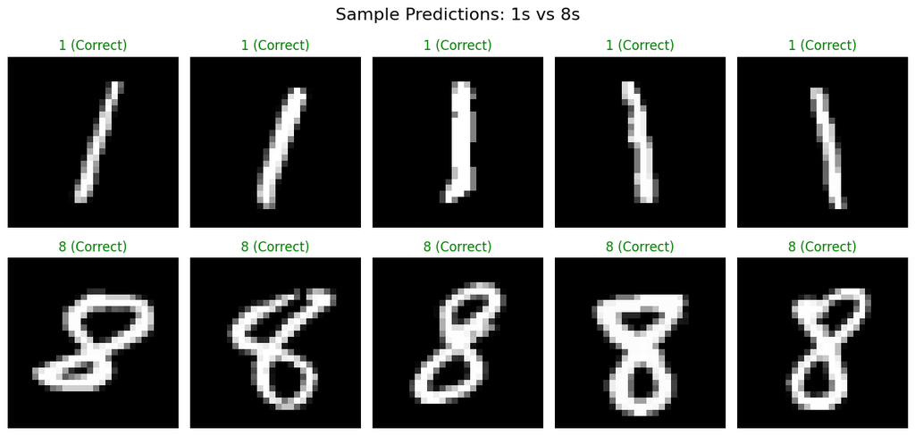

[figure not shown]

```python
# 1. Show some example images with predictions
fig, axes = plt.subplots(2, 5, figsize=(12, 6))
fig.suptitle("Sample Predictions: 1s vs 8s", fontsize=16)

# Show 5 examples of each class
for i in range(5):
    # Show a correctly classified 1
    idx_1 = np.where((y_test_binary == 0) & (y_pred == 0))[0][i]
    img_1 = X_test[idx_1].reshape(28, 28)
    axes[0, i].imshow(img_1, cmap="gray")
    axes[0, i].set_title("1 (Correct)", color="green")
    axes[0, i].axis("off")

    # Show a correctly classified 8
    idx_8 = np.where((y_test_binary == 1) & (y_pred == 1))[0][i]
    img_8 = X_test[idx_8].reshape(28, 28)
    axes[1, i].imshow(img_8, cmap="gray")
    axes[1, i].set_title("8 (Correct)", color="green")
    axes[1, i].axis("off")

plt.tight_layout()
plt.show()

# 2. Show misclassified examples
misclassified = np.where(y_test_binary != y_pred)[0]
if len(misclassified) > 0:
    fig, axes = plt.subplots(2, 5, figsize=(12, 6))
    fig.suptitle("Misclassified Examples", fontsize=16)

    for i in range(min(5, len(misclassified))):
        idx = misclassified[i]
        img = X_test[idx].reshape(28, 28)
        actual = 1 if y_test_binary[idx] == 0 else 8
        predicted = 1 if y_pred[idx] == 0 else 8

        axes[0, i].imshow(img, cmap="gray")
        axes[0, i].set_title(f"Actual: {actual}, Predicted: {predicted}", color="red")
        axes[0, i].axis("off")

    # Hide unused subplots
    for i in range(len(misclassified), 5):
        axes[0, i].axis("off")

    plt.tight_layout()
    plt.show()
```

We can even see which pixel is the most important to making the decision!

- The weights show which pixels are most important for classification"
- Red areas in the weight map favor class 1 (8s), blue areas favor class 0 (1s)

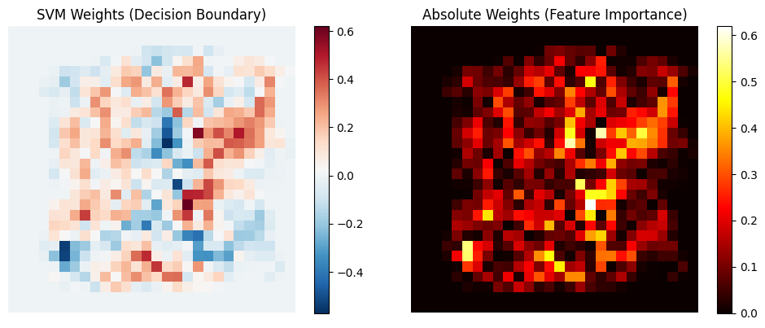

```python
# Feature importance (weights) - show the most important pixels
weights = best_svm.coef_[0].reshape(28, 28)
plt.figure(figsize=(10, 4))

plt.subplot(1, 2, 1)
plt.imshow(weights, cmap="RdBu_r")
plt.title("SVM Weights (Decision Boundary)")
plt.colorbar()
plt.axis("off")

plt.subplot(1, 2, 2)
plt.imshow(np.abs(weights), cmap="hot")
plt.title("Absolute Weights (Feature Importance)")
plt.colorbar()
plt.axis("off")

plt.tight_layout()
plt.show()
```

## (b) Polynomial Kernel SVM (degree 3)

Now an SVM with polynomial kernel: K(x, z) = (1 + x^T z)^3

⚠️ WARNING: This takes 10+ minutes to run on my computer. You can reduce the parameter grid to search across fewer parameter combinations.

```python
# Polynomial Kernel SVM with degree 3
# Define parameter grid for C and gamma (for polynomial kernel)
param_grid_poly = {
    "C": [0.001, 0.01, 0.1, 1, 10, 100],
    "gamma": ["scale", "auto", 0.001, 0.01, 0.1, 1],
}

# Create polynomial SVM
svm_poly = SVC(kernel="poly", degree=3, random_state=42)

# Perform 5-fold cross-validation
print("Training Polynomial Kernel SVM...")
grid_search_poly = GridSearchCV(
    svm_poly, param_grid_poly, cv=5, scoring="accuracy", n_jobs=-1, verbose=1
)

grid_search_poly.fit(X_train, y_train_binary)

print(f"\nBest parameters: {grid_search_poly.best_params_}")
print(f"Best cross-validation score: {grid_search_poly.best_score_:.4f}")

# Get the best model
best_svm_poly = grid_search_poly.best_estimator_
```

```
Training Polynomial Kernel SVM...
Fitting 5 folds for each of 36 candidates, totalling 180 fits

Best parameters: {'C': 0.01, 'gamma': 0.1}
Best cross-validation score: 0.9950
```

```python
# Evaluate Polynomial Kernel SVM
y_pred_poly = best_svm_poly.predict(X_test)

# Calculate accuracy
accuracy_poly = accuracy_score(y_test_binary, y_pred_poly)
print(f"Polynomial Kernel Test Accuracy: {accuracy_poly:.4f}")

# Confusion Matrix
cm_poly = confusion_matrix(y_test_binary, y_pred_poly)
print("\nPolynomial Kernel Confusion Matrix:")
print(f"True Negatives (1s): {cm_poly[0,0]}")
print(f"False Positives (1s predicted as 8s): {cm_poly[0,1]}")
print(f"False Negatives (8s predicted as 1s): {cm_poly[1,0]}")
print(f"True Positives (8s): {cm_poly[1,1]}")

# Classification Report
print("\nPolynomial Kernel Classification Report:")
print(
    classification_report(
        y_test_binary, y_pred_poly, target_names=["Digit 1", "Digit 8"]
    )
)

# Support vector analysis
print("\nPolynomial Kernel SVM Analysis:")
print(f"Number of support vectors: {best_svm_poly.n_support_}")
print(f"Support vectors for class 0 (1s): {best_svm_poly.n_support_[0]}")
print(f"Support vectors for class 1 (8s): {best_svm_poly.n_support_[1]}")
```

```
Polynomial Kernel Test Accuracy: 0.9972

Polynomial Kernel Confusion Matrix:
True Negatives (1s): 1131
False Positives (1s predicted as 8s): 4
False Negatives (8s predicted as 1s): 2
True Positives (8s): 972

Polynomial Kernel Classification Report:
              precision    recall  f1-score   support

     Digit 1       1.00      1.00      1.00      1135
     Digit 8       1.00      1.00      1.00       974

    accuracy                           1.00      2109
   macro avg       1.00      1.00      1.00      2109
weighted avg       1.00      1.00      1.00      2109


Polynomial Kernel SVM Analysis:
Number of support vectors: [249 287]
Support vectors for class 0 (1s): 249
Support vectors for class 1 (8s): 287
```

## (c) RBF Kernel SVM

FInally, an SVM with RBF (Radial Basis Function) kernel

⚠️ WARNING: This takes 20+ minutes to run on my computer. You can reduce the parameter grid to search across fewer parameter combinations.

```python
# RBF Kernel SVM
# Define parameter grid for C and gamma (for RBF kernel)
param_grid_rbf = {
    "C": [0.001, 0.01, 0.1, 1, 10, 100],
    "gamma": ["scale", "auto", 0.001, 0.01, 0.1, 1],
}

# Create RBF SVM
svm_rbf = SVC(kernel="rbf", random_state=42)

# Perform 5-fold cross-validation
print("Training RBF Kernel SVM...")
grid_search_rbf = GridSearchCV(
    svm_rbf, param_grid_rbf, cv=5, scoring="accuracy", n_jobs=-1, verbose=1
)

grid_search_rbf.fit(X_train, y_train_binary)

print(f"\nBest parameters: {grid_search_rbf.best_params_}")
print(f"Best cross-validation score: {grid_search_rbf.best_score_:.4f}")

# Get the best model
best_svm_rbf = grid_search_rbf.best_estimator_
```

```
Training RBF Kernel SVM...
Fitting 5 folds for each of 36 candidates, totalling 180 fits

Best parameters: {'C': 10, 'gamma': 'scale'}
Best cross-validation score: 0.9975
```

```python
# Evaluate RBF Kernel SVM
y_pred_rbf = best_svm_rbf.predict(X_test)

# Calculate accuracy
accuracy_rbf = accuracy_score(y_test_binary, y_pred_rbf)
print(f"RBF Kernel Test Accuracy: {accuracy_rbf:.4f}")

# Confusion Matrix
cm_rbf = confusion_matrix(y_test_binary, y_pred_rbf)
print("\nRBF Kernel Confusion Matrix:")
print(f"True Negatives (1s): {cm_rbf[0,0]}")
print(f"False Positives (1s predicted as 8s): {cm_rbf[0,1]}")
print(f"False Negatives (8s predicted as 1s): {cm_rbf[1,0]}")
print(f"True Positives (8s): {cm_rbf[1,1]}")

# Classification Report
print("\nRBF Kernel Classification Report:")
print(
    classification_report(
        y_test_binary, y_pred_rbf, target_names=["Digit 1", "Digit 8"]
    )
)

# Support vector analysis
print("\nRBF Kernel SVM Analysis:")
print(f"Number of support vectors: {best_svm_rbf.n_support_}")
print(f"Support vectors for class 0 (1s): {best_svm_rbf.n_support_[0]}")
print(f"Support vectors for class 1 (8s): {best_svm_rbf.n_support_[1]}")
```

```
RBF Kernel Test Accuracy: 0.9995

RBF Kernel Confusion Matrix:
True Negatives (1s): 1134
False Positives (1s predicted as 8s): 1
False Negatives (8s predicted as 1s): 0
True Positives (8s): 974

RBF Kernel Classification Report:
              precision    recall  f1-score   support

     Digit 1       1.00      1.00      1.00      1135
     Digit 8       1.00      1.00      1.00       974

    accuracy                           1.00      2109
   macro avg       1.00      1.00      1.00      2109
weighted avg       1.00      1.00      1.00      2109


RBF Kernel SVM Analysis:
Number of support vectors: [244 287]
Support vectors for class 0 (1s): 244
Support vectors for class 1 (8s): 287
```

```python
# Compare all three SVM models
print("=" * 60)
print("COMPARISON OF ALL THREE SVM MODELS")
print("=" * 60)

print(f"Linear SVM Accuracy:     {accuracy:.4f}")
print(f"Polynomial SVM Accuracy: {accuracy_poly:.4f}")
print(f"RBF SVM Accuracy:       {accuracy_rbf:.4f}")

print(f"\nLinear SVM Support Vectors:     {best_svm.n_support_}")
print(f"Polynomial SVM Support Vectors: {best_svm_poly.n_support_}")
print(f"RBF SVM Support Vectors:        {best_svm_rbf.n_support_}")

print(f"\nLinear SVM Best C:     {grid_search.best_params_}")
print(f"Polynomial SVM Best:   {grid_search_poly.best_params_}")
print(f"RBF SVM Best:          {grid_search_rbf.best_params_}")

# Show which model performs best
models = ["Linear", "Polynomial", "RBF"]
accuracies = [accuracy, accuracy_poly, accuracy_rbf]
best_model_idx = np.argmax(accuracies)
print(
    f"\nBest performing model: {models[best_model_idx]} SVM with {accuracies[best_model_idx]:.4f} accuracy"
)
```

```
============================================================
COMPARISON OF ALL THREE SVM MODELS
============================================================
Linear SVM Accuracy:     0.9915
Polynomial SVM Accuracy: 0.9972
RBF SVM Accuracy:       0.9995

Linear SVM Support Vectors:     [296 307]
Polynomial SVM Support Vectors: [249 287]
RBF SVM Support Vectors:        [244 287]

Linear SVM Best C:     {'C': 0.1}
Polynomial SVM Best:   {'C': 0.01, 'gamma': 0.1}
RBF SVM Best:          {'C': 10, 'gamma': 'scale'}

Best performing model: RBF SVM with 0.9995 accuracy
```

Pretty cool...